# assignment-615-cleaning-data

```r
library(tidyverse)
library(slider)
```

## Data Upload

```r
Strawberry <- read.csv("1583F9B0-866A-3858-8AC9-7E9F576AEE9F.csv")
glimpse(Strawberry)
```

```
Rows: 21,341
Columns: 21
$ Program          <chr> "CENSUS", "CENSUS", "CENSUS", "CENSUS", "CENSUS", "CE…
$ Year             <int> 2022, 2022, 2022, 2022, 2022, 2022, 2022, 2022, 2022,…
$ Period           <chr> "YEAR", "YEAR", "YEAR", "YEAR", "YEAR", "YEAR", "YEAR…
$ Week.Ending      <lgl> NA, NA, NA, NA, NA, NA, NA, NA, NA, NA, NA, NA, NA, N…
$ Geo.Level        <chr> "STATE", "STATE", "STATE", "STATE", "STATE", "STATE",…
$ State            <chr> "ALABAMA", "ALABAMA", "ALABAMA", "ALABAMA", "ALABAMA"…
$ State.ANSI       <int> 1, 1, 1, 1, 1, 1, 2, 2, 2, 2, 2, 2, 4, 4, 4, 4, 4, 4,…
$ Ag.District      <lgl> NA, NA, NA, NA, NA, NA, NA, NA, NA, NA, NA, NA, NA, N…
$ Ag.District.Code <lgl> NA, NA, NA, NA, NA, NA, NA, NA, NA, NA, NA, NA, NA, N…
$ County           <lgl> NA, NA, NA, NA, NA, NA, NA, NA, NA, NA, NA, NA, NA, N…
$ County.ANSI      <lgl> NA, NA, NA, NA, NA, NA, NA, NA, NA, NA, NA, NA, NA, N…
$ Zip.Code         <lgl> NA, NA, NA, NA, NA, NA, NA, NA, NA, NA, NA, NA, NA, N…
$ Region           <lgl> NA, NA, NA, NA, NA, NA, NA, NA, NA, NA, NA, NA, NA, N…
$ watershed_code   <int> 0, 0, 0, 0, 0, 0, 0, 0, 0, 0, 0, 0, 0, 0, 0, 0, 0, 0,…
$ Watershed        <lgl> NA, NA, NA, NA, NA, NA, NA, NA, NA, NA, NA, NA, NA, N…
$ Commodity        <chr> "STRAWBERRIES", "STRAWBERRIES", "STRAWBERRIES", "STRA…
$ Data.Item        <chr> "STRAWBERRIES - ACRES BEARING", "STRAWBERRIES - ACRES…
$ Domain           <chr> "TOTAL", "TOTAL", "TOTAL", "TOTAL", "TOTAL", "TOTAL",…
$ Domain.Category  <chr> "NOT SPECIFIED", "NOT SPECIFIED", "NOT SPECIFIED", "N…
$ Value            <chr> "162", "171", "9", "107", "119", "18", "11", "14", "3…
$ CV....           <chr> "16.9", "17.5", "80.0", "19.7", "17.5", "26.9", "(L)"…
```

## Data Cleaning

```r
# drop columns that have only a single distinct value
drop_one_value_col <- function(df) {
  keep <- vapply(df, function(x) dplyr::n_distinct(x, na.rm = FALSE) > 1, logical(1))
  df[, keep, drop = FALSE]
}

Strawberry_clean1 <- drop_one_value_col(Strawberry)

Strawberry_clean1$Domain.Category <- trimws(sub(".*:", "", Strawberry_clean1$Domain.Category))
Strawberry_clean1$Data.Item       <- trimws(sub(".*-", "", Strawberry_clean1$Data.Item))
Strawberry_clean1$Value <- ifelse(Strawberry_clean1$Value %in% c(" (NA)"), NA, Strawberry_clean1$Value)

Strawberry_clean2 <- Strawberry_clean1 %>%
  filter(grepl("HERB", Domain, ignore.case = TRUE)) %>%
  mutate(Domain = str_c(Domain, Domain.Category, sep = ": ")) %>%
  select(-Domain.Category)

Strawberry_clean2_summarised <- Strawberry_clean2 %>%
  group_by(Program, Year, State, Domain, Data.Item) %>%
  summarise(Value = max(Value, na.rm = TRUE), .groups = "drop")

strawberry_wide <- Strawberry_clean2_summarised %>%
  tidyr::pivot_wider(
    id_cols = c(Program, Year, State, Domain),
    names_from = Data.Item,
    values_from = Value
  )
```

```r
## Keep ONLY years with BOTH Herbicide & Organic data (1990+)
states_both <- tibble(Year = 1990:max(as.integer(c(strawberry_wide$Year, Strawberry$Year)), na.rm = TRUE)) %>%
  left_join(
    strawberry_wide %>%
      mutate(Year = suppressWarnings(as.integer(Year))) %>%
      filter(!is.na(Year), nzchar(State)) %>%
      group_by(Year) %>% summarise(h = list(sort(unique(State))), .groups = "drop"),
    by = "Year"
  ) %>%
  left_join(
    Strawberry %>%
      filter(grepl("ORGANIC STATUS", Domain, ignore.case = TRUE)) %>%
      mutate(Year = suppressWarnings(as.integer(Year))) %>%
      filter(!is.na(Year), nzchar(State)) %>%
      group_by(Year) %>% summarise(o = list(sort(unique(State))), .groups = "drop"),
    by = "Year"
  ) %>%
  mutate(both = purrr::map2(h, o, ~{
    a <- if (is.null(.x)) character(0) else .x
    b <- if (is.null(.y)) character(0) else .y
    sort(intersect(a, b))
  })) %>%
  filter(lengths(both) > 0) %>%
  transmute(
    Year,
    `States with both` = purrr::map_chr(both, ~ paste(.x, collapse = ", "))
  ) %>%
  arrange(Year)

states_both
```

```
# A tibble: 4 × 2
   Year `States with both`
  <int> <chr>
1  2014 CALIFORNIA, FLORIDA, OREGON, WASHINGTON
2  2016 CALIFORNIA, FLORIDA, OREGON, WASHINGTON
3  2019 CALIFORNIA, FLORIDA
4  2021 CALIFORNIA, FLORIDA
```

## Figures

### Helpers

```r
parse_num <- function(x) readr::parse_number(as.character(x))

theme_set(theme_minimal(base_size = 12))
```

### 1) Herbicide Coverage Over Time (Raw Points)

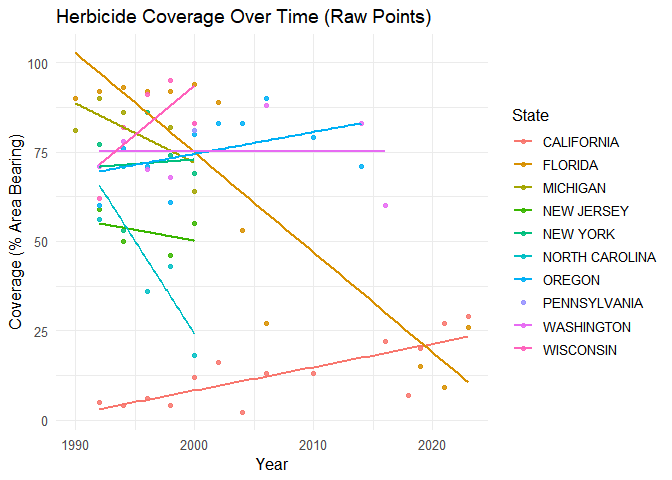

```r
herb_cov <- strawberry_wide %>%
  filter(Domain == "CHEMICAL, HERBICIDE: (TOTAL)") %>%
  transmute(
    Year  = as.integer(Year),
    State = State,
    coverage_pct = parse_num(`TREATED, MEASURED IN PCT OF AREA BEARING, AVG`)
  ) %>%
  drop_na(coverage_pct)

ggplot(herb_cov, aes(Year, coverage_pct, color = State)) +
  geom_point(alpha = .85, size = 1.6) +
  geom_smooth(method = "lm", se = FALSE) +
  labs(
    title = "Herbicide Coverage Over Time (Raw Points)",
    x = "Year", y = "Coverage (% Area Bearing)"
  )
```

### 2) Organic Share Over Time (Raw Points)

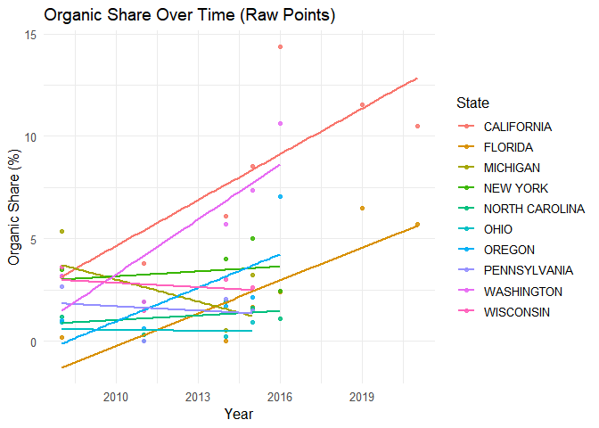

```r
# Numerator: prioritize "NOP USDA CERTIFIED & EXEMPT (TOTAL)"; else CERTIFIED + EXEMPT
org_num <- Strawberry %>%
  filter(grepl("ORGANIC STATUS", Domain,  ignore.case = TRUE),
         grepl("ORGANIC - ACRES HARVESTED", `Data.Item`, ignore.case = TRUE),
         grepl("STRAWBERR", Commodity, ignore.case = TRUE)) %>%
  mutate(val = parse_num(Value)) %>%
  group_by(Year, State) %>%
  summarise(
    organic_acres = {
      v_both <- val[grepl("CERTIFIED\\s*&\\s*EXEMPT", `Domain.Category`, ignore.case = TRUE)]
      if (length(na.omit(v_both)) > 0) sum(v_both, na.rm = TRUE)
      else sum(val[grepl("CERTIFIED|EXEMPT", `Domain.Category`, ignore.case = TRUE)], na.rm = TRUE)
    },
    .groups = "drop"
  )

# Denominator: TOTAL ACRES HARVESTED (non-organic-status)
den <- Strawberry %>%
  filter(Domain == "TOTAL",
         grepl("ACRES HARVESTED", `Data.Item`, ignore.case = TRUE),
         grepl("STRAWBERR", Commodity,   ignore.case = TRUE)) %>%
  mutate(total_acres = parse_num(Value)) %>%
  group_by(Year, State) %>%
  summarise(total_acres = sum(total_acres, na.rm = TRUE), .groups = "drop")

org_share <- org_num %>%
  inner_join(den, by = c("Year","State")) %>%
  mutate(
    Year = as.integer(Year),
    organic_share_pct = (organic_acres / ifelse(total_acres > 0, total_acres, NA)) * 100
  ) %>%
  select(Year, State, organic_share_pct) %>%
  filter(is.finite(organic_share_pct))

ggplot(org_share, aes(Year, organic_share_pct, color = State)) +
  geom_point(alpha = .85, size = 1.6) +
  geom_smooth(method = "lm", se = FALSE) +
  labs(
    title = "Organic Share Over Time (Raw Points)",
    x = "Year", y = "Organic Share (%)"
  )
```

### 3) Organic Share vs Herbicide Coverage (Raw, by Year-State)

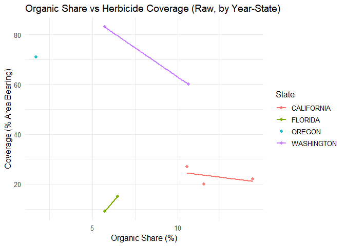

```r
merged_raw <- inner_join(herb_cov, org_share, by = c("Year","State")) %>%
  drop_na(coverage_pct, organic_share_pct)

ggplot(merged_raw, aes(organic_share_pct, coverage_pct, color = State)) +
  geom_point(alpha = .9, size = 1.8) +
  geom_smooth(method = "lm", se = FALSE) +
  labs(
    title = "Organic Share vs Herbicide Coverage (Raw, by Year-State)",
    x = "Organic Share (%)", y = "Coverage (% Area Bearing)"
  )
```

### 4) Organic Share vs Herbicide Coverage (3-Year Centered, Loose)

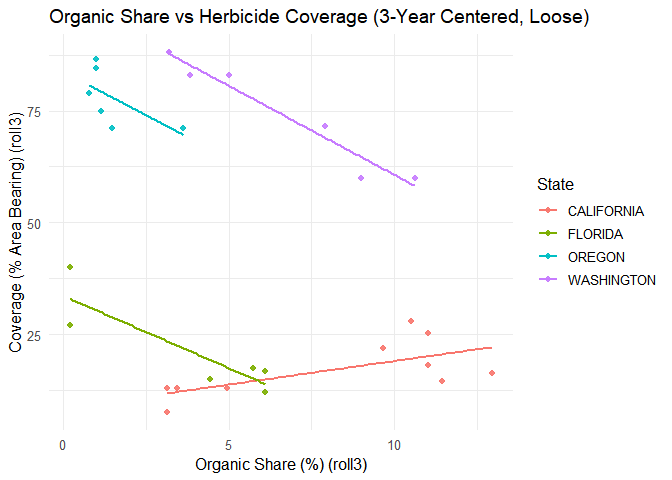

```r
panel <- tidyr::expand_grid(
  State = union(herb_cov$State, org_share$State),
  Year  = union(herb_cov$Year,  org_share$Year)
) %>%
  left_join(herb_cov, by = c("State","Year")) %>%
  left_join(org_share, by = c("State","Year")) %>%
  group_by(State) %>% arrange(Year, .by_group = TRUE) %>%
  mutate(
    coverage_pct_roll3 = slide_dbl(
      coverage_pct,
      ~ if (all(is.na(.x))) NA_real_ else mean(.x, na.rm = TRUE),
      .before = 1, .after = 1
    ),
    organic_share_pct_roll3 = slide_dbl(
      organic_share_pct,
      ~ if (all(is.na(.x))) NA_real_ else mean(.x, na.rm = TRUE),
      .before = 1, .after = 1
    )
  ) %>%
  ungroup() %>%
  drop_na(coverage_pct_roll3, organic_share_pct_roll3)

ggplot(panel, aes(organic_share_pct_roll3, coverage_pct_roll3, color = State)) +
  geom_point(alpha = .9, size = 1.8) +
  geom_smooth(method = "lm", se = FALSE) +
  labs(
    title = "Organic Share vs Herbicide Coverage (3-Year Centered, Loose)",
    x = "Organic Share (%) (roll3)", y = "Coverage (% Area Bearing) (roll3)"
  )
```

### 图 1：覆盖率时序（原始点）

- **时间结构**：早期（1990s）若干州点位密集，**2008 年后覆盖率数据显著稀疏**，导致近年的跨州比较受限。
- **解读**：覆盖率反映“**常规**草莓可结果面积中使用任一除草剂的比例”，受当年杂草压力、种植规模、劳力价格和替代技术（覆盖地膜、机械除草）共同影响，不直接等价于“用药强度”。

### 图 2：有机占比时序（原始点）

- **趋势**：总体呈**温和上升**，但州际差异明显；个别州在 2008–2020 年期间的增长较为突出。
- **口径性差异**：有机占比以“**收获面积**”计量，与覆盖率的“**结果面积**”并非同一母体；若州内有机扩张集中在特定生产带，其对常规区的结构性挤出与技术外溢方向不一。
- **数据可及性**：与覆盖率相似，完整的年序列并不多，部分年份存在抑制/缺失编码（如 `(D)`, `(NA)`, `(Z)`）转为缺失后可用点减少。

### 图 3：有机占比 vs 覆盖率（原始匹配，year–state）

- **重叠稀少**：有效匹配仅 **8** 个点，**相关方向不具统计代表性**。这是由于两个体系在同年同州能同时满足“TOTAL 覆盖率”与“有机分子/分母”可用的记录非常有限。
- **启示**：在如此小样本下，任何线性关系都可能由时间趋势或异常年驱动，难以得出稳健结论。

### 图 4：有机占比 vs 覆盖率（3 年中心–宽松）

- **方法收益**：采用 ([t-1,t,t+1]) 居中窗口并允许缺值（min_periods=1）后，有效点增至 **31**，重叠显著改善。
- **方向性特征**：**多数州（3 个）呈负相关**——有机占比越高，常规区覆盖率越低；**少数州（1 个）呈正相关**——有机占比上升与覆盖率同步走高。

**结论**：在现有可用数据下，滚动口径揭示了“有机占比提升与常规覆盖率下降**在多数州并存**”的趋势，但存在反例。